# Feature importance and bootstrap selection stability

Deep immune cell phenotyping predicts influenza vaccine immunogenicity in HCT recipients

July 21, 2026

# 1 What this notebook does

This notebook asks which cellular-composition features drive the prediction, and whether those choices are stable rather than accidents of the particular patients sampled. It produces:

- **Figure 4** – signed feature importance in the full model (M4).
- **Supplementary Figure (stability landscape)** – selection frequency versus sign consistency for every cluster feature.
- **Supplementary Figure (selection frequency)** – how often each cluster feature is selected across bootstraps.
- **Supplementary Figure (coefficient distributions)** – the spread of each stable feature’s coefficient across bootstraps.

The stability analysis resamples patients 200 times (with the regularization strength held fixed at the full-sample value) and refits the elastic net on the **production atlas**, recording which features are kept and with what coefficient each time. Because this uses a single all-patient atlas, it carries a small amount of representation leakage and is used only for descriptive stability, not for the performance claims (those rest on the leakage-free per-fold pipeline in notebooks 01–02).

```r
# Edit these to your local copy of the intermediate data (not distributed; see
# README, Data Availability).
REPO <- "/home/amir/repo/flu-cellular-prediction"

BOOT_FILE <- file.path(REPO, "results", "final_atlas_production", "bootstrap_importance_a6fd33eb.RData")
BIO_FILE  <- file.path(REPO, "results", "final_atlas_production", "biology_production_90203bf3.RData")
ATLAS_FILE <- file.path(REPO, "results", "final_atlas_production", "final_atlas_e862228d.RData")
ANN_FILE  <- file.path(REPO, "results", "reports", "cluster_annotations_corrected.csv")

VIRUSES <- c("h1n1", "h3n2", "bvic")
```

```r
if (file.exists(BOOT_FILE)) {
  # Load the 200-bootstrap coefficient records (fast: no refitting).
  boot <- new.env(parent = emptyenv()); load(BOOT_FILE, envir = boot)
} else {
  # ---- Self-contained bootstrap refit on the production atlas. Needs the
  #      production-atlas feature matrix (X_clust) and outcomes (Y_mat) from
  #      final_atlas_*.RData, but no raw cells. Runs ~200 glmnet fits. ----
  if (!file.exists(ATLAS_FILE))
    stop("Neither the bootstrap cache nor the production atlas was found.")
  a <- new.env(parent = emptyenv()); load(ATLAS_FILE, envir = a)
  suppressPackageStartupMessages(library(glmnet))
  set.seed(7000L); n <- nrow(a$X_clust); recs <- list()
  for (b in seq_len(200L)) {
    idx <- sample.int(n, n, replace = TRUE)
    fit <- glmnet(a$X_clust[idx, ], a$Y_mat[idx, ], family = "mgaussian",
                  alpha = a$ALPHA, lambda = a$cv_fit$lambda.min)
    cf <- coef(fit)
    recs[[b]] <- rbindlist(lapply(VIRUSES, function(v) data.table(
      bootstrap = b, virus = v, feature = rownames(cf[[v]]),
      coef = as.numeric(cf[[v]]))))
  }
  boot <- new.env(); boot$coef_dt <- rbindlist(recs)
  stop("Bootstrap refit complete; re-save as ", BOOT_FILE, " to cache it.")
}
coef_dt   <- as.data.table(boot$coef_dt)
stability <- as.data.table(boot$stability)
lambda_ref <- boot$lambda_ref

# Curated annotations for readable feature labels.
ann <- as.data.table(read.csv(ANN_FILE, stringsAsFactors = FALSE))
ann[, cluster_id := as.integer(cluster_id)]
# Short label = annotation with any parenthetical qualifier removed.
ann[, short := trimws(gsub("\\s+", " ", gsub("\\s*\\(.*?\\)", "", annotation)))]

cat("Bootstraps:", uniqueN(coef_dt$bootstrap), "\n")
```

```
## Bootstraps: 200
```

```r
cat("Fixed lambda.min:", round(lambda_ref, 4), "\n")
```

```
## Fixed lambda.min: 0.0995
```

# 2 Figure 4: signed feature importance in the full model (M4)

Each feature’s importance is its elastic-net coefficient multiplied by the feature’s standard deviation, averaged across the 200 bootstraps. Multiplying by the standard deviation puts features on a comparable scale (importance per typical swing in the feature). The sign is kept: bars to the right (red) are positive predictors of the fold-rise; bars to the left (blue) are negative. Baseline titers dominate the magnitude in every antigen – negative, because a higher pre-vaccination titer predicts a smaller fold-rise.

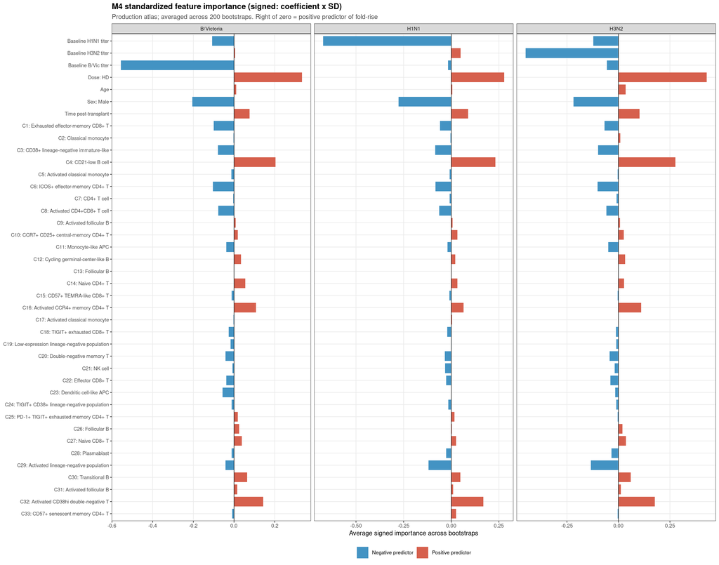

```r
bio <- new.env(parent = emptyenv()); load(BIO_FILE, envir = bio)
clr_sd <- apply(bio$clr_features, 2, sd)               # SD of each cluster feature
sd_dt  <- data.table(feature = names(clr_sd), sd = as.numeric(clr_sd))

# Mean signed coefficient per feature and antigen, times the feature SD.
agg <- coef_dt[feature != "(Intercept)",
               .(mean_coef = mean(coef)), by = .(virus, feature)]
agg <- merge(agg, sd_dt, by = "feature", all.x = TRUE)
agg[is.na(sd), sd := 1]                                # covariates: unit scale
agg[, signed_imp := mean_coef * sd]

# Readable labels: cluster features get "C<id>: <cell type>"; covariates get
# plain-English names. Covariates are listed first, then clusters numerically.
agg[, is_cluster := grepl("^cluster_", feature)]
agg[, cluster_id := ifelse(is_cluster, as.integer(sub("cluster_", "", feature)), NA_integer_)]
cov_pretty <- c(baseline_h1n1 = "Baseline H1N1 titer", baseline_h3n2 = "Baseline H3N2 titer",
                baseline_bvic = "Baseline B/Vic titer", dose_HD = "Dose: HD", age = "Age",
                sex_Male = "Sex: Male", time_post_transplant = "Time post-transplant")
cov_order <- names(cov_pretty)
short_lu <- setNames(ann$short, as.character(ann$cluster_id))   # cluster id -> short name
agg[, display_label := ifelse(is_cluster,
  sprintf("C%d: %s", cluster_id, short_lu[as.character(cluster_id)]),
  ifelse(feature %in% names(cov_pretty), cov_pretty[feature], feature))]
agg[, sort_key := ifelse(is_cluster, 1000L + cluster_id, match(feature, cov_order))]
agg <- agg[!is.na(sort_key)]
agg[, display_label := factor(display_label,
                              levels = unique(agg[order(-sort_key), display_label]))]

ggplot(agg, aes(display_label, signed_imp, fill = signed_imp > 0)) +
  geom_col(width = 0.8) +
  geom_hline(yintercept = 0, linewidth = 0.3) +
  coord_flip() +
  facet_wrap(~ virus, ncol = 3, scales = "free_x",
             labeller = labeller(virus = c(h1n1 = "H1N1", h3n2 = "H3N2", bvic = "B/Victoria"))) +
  scale_fill_manual(values = c("TRUE" = "#d6604d", "FALSE" = "#4393c3"),
                    labels = c("TRUE" = "Positive predictor", "FALSE" = "Negative predictor"),
                    name = NULL) +
  labs(title = "M4 standardized feature importance (signed: coefficient x SD)",
       subtitle = "Production atlas; averaged across 200 bootstraps. Right of zero = positive predictor of fold-rise",
       x = NULL, y = "Average signed importance across bootstraps") +
  theme_bw(base_size = 9) +
  theme(plot.title = element_text(face = "bold", size = 11),
        plot.subtitle = element_text(size = 9, color = "gray30"),
        axis.text.y = element_text(size = 7), legend.position = "bottom",
        panel.grid.minor = element_blank())
```

Among the cluster features, the CD21-low B cell subset (C4) and the activated CD38-high double-negative T cell (C32) are the strongest positive predictors, while several CD4+ memory and APC subsets contribute negatively – best read, in a compositional representation, as markers of an incomplete reconstitution state where the mature response-driving populations have not yet expanded.

# 3 Supplementary Figure: stability landscape

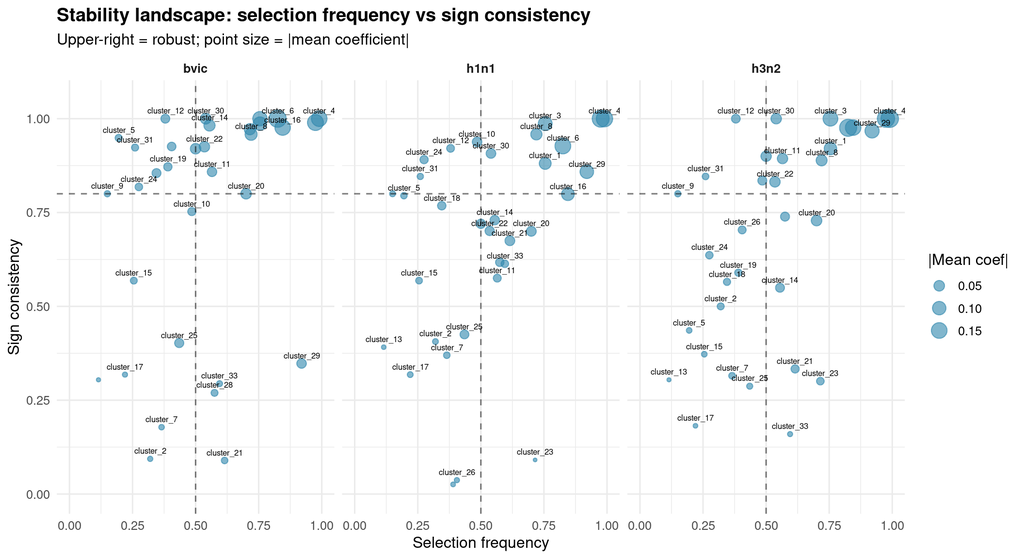

```r
cluster_stab <- stability[grepl("^cluster_", feature)]
ggplot(cluster_stab, aes(selection_freq, sign_consistency,
                         size = abs(mean_coef), label = feature)) +
  geom_point(alpha = 0.6, color = "#2E86AB") +
  geom_text(size = 2.2, vjust = -0.8, check_overlap = TRUE, show.legend = FALSE) +
  geom_vline(xintercept = 0.5, linetype = "dashed", alpha = 0.5) +
  geom_hline(yintercept = 0.8, linetype = "dashed", alpha = 0.5) +
  facet_wrap(~ virus) +
  scale_x_continuous(limits = c(0, 1)) +
  scale_y_continuous(limits = c(0, 1.05)) +
  labs(title = "Stability landscape: selection frequency vs sign consistency",
       subtitle = "Upper-right = robust; point size = |mean coefficient|",
       x = "Selection frequency", y = "Sign consistency", size = "|Mean coef|") +
  theme_minimal(base_size = 12) +
  theme(plot.title = element_text(face = "bold"), strip.text = element_text(face = "bold"))
```

# 4 Supplementary Figure: selection frequency

The multitask elastic net enforces the same sparsity pattern across all three antigens (a feature is selected for all three or none), so selection frequency is identical across antigens and one panel suffices. The dashed line marks 50% and the dotted line 90%.

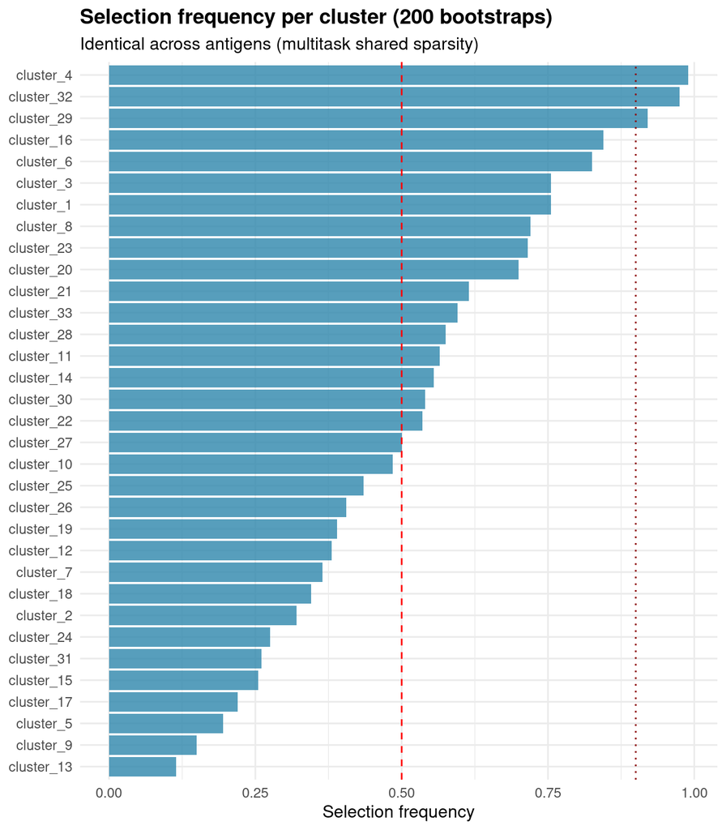

```r
sel_single <- cluster_stab[virus == VIRUSES[1]]
ggplot(sel_single, aes(reorder(feature, selection_freq), selection_freq)) +
  geom_col(fill = "#2E86AB", alpha = 0.8) +
  geom_hline(yintercept = 0.5, linetype = "dashed", color = "red") +
  geom_hline(yintercept = 0.9, linetype = "dotted", color = "darkred") +
  coord_flip() +
  labs(title = "Selection frequency per cluster (200 bootstraps)",
       subtitle = "Identical across antigens (multitask shared sparsity)",
       x = NULL, y = "Selection frequency") +
  theme_minimal(base_size = 12) +
  theme(plot.title = element_text(face = "bold"))
```

```r
# How many clusters clear each selection-frequency threshold (per antigen).
counts <- rbindlist(lapply(VIRUSES, function(v) data.table(
  antigen = v,
  `>=50%` = cluster_stab[virus == v & selection_freq >= 0.5, .N],
  `>=90%` = cluster_stab[virus == v & selection_freq >= 0.9, .N])))
kable(counts, caption = "Clusters selected above each stability threshold, per antigen.")
```

Clusters selected above each stability threshold, per antigen.

| antigen | >=50% | >=90% |
| --- | --- | --- |
| h1n1 | 18 | 3 |
| h3n2 | 18 | 3 |
| bvic | 18 | 3 |

The most reliably selected features are cluster 4 (CD21-low B, 99.0%) and cluster 32 (activated double-negative T, 97.5%). Eighteen of 33 clusters are selected in at least half of bootstraps for each antigen, and every feature that is stable in one antigen is stable in all three – a pan-influenza signature rather than antigen-specific noise.

# 5 Supplementary Figure: coefficient distributions

For the stably selected features, the coefficient’s spread across bootstraps shows whether the effect size (not just the selection) is reproducible. Tight boxes mean the elastic net assigns each feature a consistent weight.

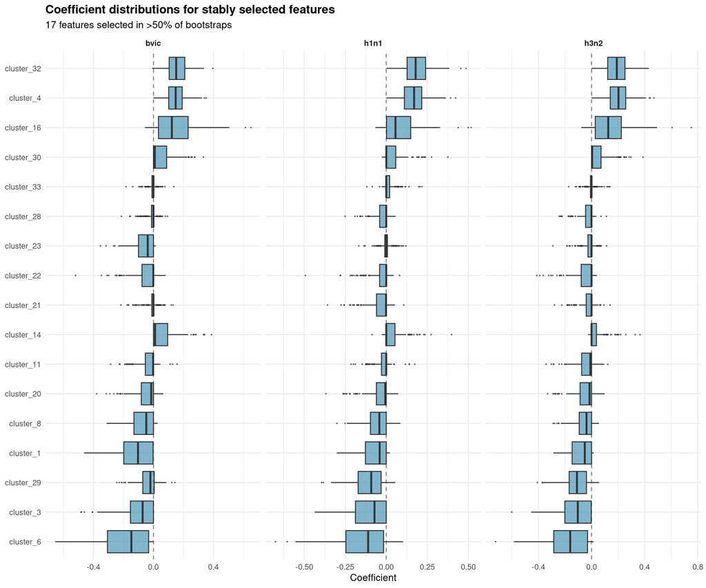

```r
stable_features <- cluster_stab[selection_freq > 0.5, unique(feature)]
coef_stable <- coef_dt[feature %in% stable_features]
ggplot(coef_stable, aes(reorder(feature, coef, FUN = median), coef)) +
  geom_hline(yintercept = 0, linetype = "dashed", color = "gray50") +
  geom_boxplot(fill = "#2E86AB", alpha = 0.6, outlier.size = 0.3) +
  coord_flip() +
  facet_wrap(~ virus, scales = "free_x") +
  labs(title = "Coefficient distributions for stably selected features",
       subtitle = sprintf("%d features selected in >50%% of bootstraps", length(stable_features)),
       x = NULL, y = "Coefficient") +
  theme_minimal(base_size = 12) +
  theme(plot.title = element_text(face = "bold"), strip.text = element_text(face = "bold"))
```